# Introduction to R

2021-03-08

## Outline

- Basic concepts
- Importing/exporting data
- Summarizing data
- Visualizing data
- Modeling data
- Control flow
- Iteration
- Scripts

## What is R?

- A programming environment and language for statistical computing and graphics
  - A multi-paradigm programming language
  - A high-level (human-friendly) interpreted scripting language

## Why R?

- designed for statistical computing
- free/libre/open source
- diverse community of users

## Installing R

Instructions on [CRAN](https://cran.r-project.org/)

## Using R

Command-line interface (CLI):

- Interactive mode: `R`
- Batch mode: `Rscript`

On CARC systems: `module load r`

## R console

To start a new interactive R session:

```r
$ R

R version 4.0.0 (2020-04-24) -- "Arbor Day"
Copyright (C) 2020 The R Foundation for Statistical Computing
Platform: x86_64-pc-linux-gnu (64-bit)

R is free software and comes with ABSOLUTELY NO WARRANTY.
You are welcome to redistribute it under certain conditions.
Type 'license()' or 'licence()' for distribution details.

  Natural language support but running in an English locale

R is a collaborative project with many contributors.
Type 'contributors()' for more information and
'citation()' on how to cite R or R packages in publications.

Type 'demo()' for some demos, 'help()' for on-line help, or
'help.start()' for an HTML browser interface to help.
Type 'q()' to quit R.

>
```

## Basic concepts

- Base R and packages
- Objects
- Data types and structures
- Functions

## Base R and packages

- A package is a formal collection of related R functions, objects, classes, etc.
- Base R is a stable set of core packages
- Some base packages are loaded automatically when starting a new R session
- Other packages that extend base R need to be installed
- There’s more than one way to do something in R

## R sessions

```r
> sessionInfo()
R version 4.0.0 (2020-04-24)
Platform: x86_64-pc-linux-gnu (64-bit)
Running under: CentOS Linux 7 (Core)

Matrix products: default
BLAS:   /R/4.0.0/lib64/R/lib/libRblas.so
LAPACK: /R/4.0.0/lib64/R/lib/libRlapack.so

locale:
 [1] LC_CTYPE=en_US.UTF-8       LC_NUMERIC=C
 [3] LC_TIME=en_US.UTF-8        LC_COLLATE=en_US.UTF-8
 [5] LC_MONETARY=en_US.UTF-8    LC_MESSAGES=en_US.UTF-8
 [7] LC_PAPER=en_US.UTF-8       LC_NAME=C
 [9] LC_ADDRESS=C               LC_TELEPHONE=C
[11] LC_MEASUREMENT=en_US.UTF-8 LC_IDENTIFICATION=C

attached base packages:
[1] stats     graphics  grDevices utils     datasets  methods   base

loaded via a namespace (and not attached):
[1] compiler_4.0.0
```

*To quit, enter `q()`*

## Arithmetic operators

- `+` → addition
- `-` → subtraction
- `*` → multiplication
- `/` → division
- `^` → exponentiation
- `%/%` → integer division
- `%%` → modulo

Example for addition:

```r
2 + 2
```

```
## [1] 4
```

## Objects and functions

Two fundamental principles:

1. Everything that exists in R is an **object**
2. Everything that happens in R is a **function** call

## Objects

- An object is anything stored in the R environment
- Typically a data structure with associated attributes
- A data structure is composed of data types
- Could also be a function, a plot, etc.

## Data types

Atomic types:

- double (aka numeric, floating point)
- integer (aka numeric)
- complex
- character (string)
- logical (`TRUE` / `FALSE`)
- raw

Other classes based on atomic types:

- factor (categorical, based on integer)
- Date, POSIXct, POSIXlt, difftime (based on double)

## Data structures

Based on dimensions and mix of data types:

| Dimensions | Homogeneous | Heterogeneous |
| --- | --- | --- |
| 1d | atomic vector | list |
| 2d | matrix | data frame |
| nd | array |  |

## Creating objects

Assign value to a name. Example for a simple vector:

```r
vec <- c(1, 2, 3, 4)
```

`vec` is the name of the object

`<-` is the assignment operator

`c(1, 2, 3, 4)` is the value of the object

```r
str(vec)
```

```
##  num [1:4] 1 2 3 4
```

Use `ls()` to list objects  
Use `rm()` to remove objects

## The data frame

- Most used data structure
- Mix of numeric, character, factor, etc.

```r
head(iris)
```

```
##   Sepal.Length Sepal.Width Petal.Length Petal.Width Species
## 1          5.1         3.5          1.4         0.2  setosa
## 2          4.9         3.0          1.4         0.2  setosa
## 3          4.7         3.2          1.3         0.2  setosa
## 4          4.6         3.1          1.5         0.2  setosa
## 5          5.0         3.6          1.4         0.2  setosa
## 6          5.4         3.9          1.7         0.4  setosa
```

```r
str(iris)
```

```
## 'data.frame':    150 obs. of  5 variables:
##  $ Sepal.Length: num  5.1 4.9 4.7 4.6 5 5.4 4.6 5 4.4 4.9 ...
##  $ Sepal.Width : num  3.5 3 3.2 3.1 3.6 3.9 3.4 3.4 2.9 3.1 ...
##  $ Petal.Length: num  1.4 1.4 1.3 1.5 1.4 1.7 1.4 1.5 1.4 1.5 ...
##  $ Petal.Width : num  0.2 0.2 0.2 0.2 0.2 0.4 0.3 0.2 0.2 0.1 ...
##  $ Species     : Factor w/ 3 levels "setosa","versicolor",..: 1 1 1 1 1 1 1 1 1 1 ...
```

## The functional perspective

R is best used as a functional programming language

input object (argument) → `function()` → output object (value)

For example:

data frame → `summary()` → table of summary statistics

## Functions

A function is a unit of code that takes an input and produces an output

Generic structure of functions in R:

```r
func(arg1, arg2, ...)
```

- `func` → function name
- `arg1`, `arg2` → arguments passed to function
- `...` → other optional arguments

*Arguments can be optional and may also have default values*

*Sometimes argument names should be made explicit when assigning values (e.g., `arg3 = value`)*

## Function example: `summary()`

```r
summary(iris)
```

```
##   Sepal.Length   Sepal.Width    Petal.Length   Petal.Width        Species
##  Min.   :4.30   Min.   :2.00   Min.   :1.00   Min.   :0.1   setosa    :50
##  1st Qu.:5.10   1st Qu.:2.80   1st Qu.:1.60   1st Qu.:0.3   versicolor:50
##  Median :5.80   Median :3.00   Median :4.35   Median :1.3   virginica :50
##  Mean   :5.84   Mean   :3.06   Mean   :3.76   Mean   :1.2
##  3rd Qu.:6.40   3rd Qu.:3.30   3rd Qu.:5.10   3rd Qu.:1.8
##  Max.   :7.90   Max.   :4.40   Max.   :6.90   Max.   :2.5
```

```r
summary(iris, digits = 5)
```

```
##   Sepal.Length     Sepal.Width      Petal.Length    Petal.Width           Species
##  Min.   :4.3000   Min.   :2.0000   Min.   :1.000   Min.   :0.1000   setosa    :50
##  1st Qu.:5.1000   1st Qu.:2.8000   1st Qu.:1.600   1st Qu.:0.3000   versicolor:50
##  Median :5.8000   Median :3.0000   Median :4.350   Median :1.3000   virginica :50
##  Mean   :5.8433   Mean   :3.0573   Mean   :3.758   Mean   :1.1993
##  3rd Qu.:6.4000   3rd Qu.:3.3000   3rd Qu.:5.100   3rd Qu.:1.8000
##  Max.   :7.9000   Max.   :4.4000   Max.   :6.900   Max.   :2.5000
```

Can also use syntax `package::func()` (if package is not loaded)

## Nesting functions

```r
str(summary(iris))
```

```
##  'table' chr [1:6, 1:5] "Min.   :4.30  " "1st Qu.:5.10  " "Median :5.80  " "Mean   :5.84  " ...
##  - attr(*, "dimnames")=List of 2
##   ..$ : chr [1:6] "" "" "" "" ...
##   ..$ : chr [1:5] " Sepal.Length" " Sepal.Width" " Petal.Length" " Petal.Width" ...
```

Alternative approach:

```r
sum <- summary(iris)
str(sum)
```

```
##  'table' chr [1:6, 1:5] "Min.   :4.30  " "1st Qu.:5.10  " "Median :5.80  " "Mean   :5.84  " ...
##  - attr(*, "dimnames")=List of 2
##   ..$ : chr [1:6] "" "" "" "" ...
##   ..$ : chr [1:5] " Sepal.Length" " Sepal.Width" " Petal.Length" " Petal.Width" ...
```

```r
rm(sum)
```

## Creating functions

Define a function and assign it a name

Simple example:

```r
math <- function(x, y) {
  z <- x + y
  z * x
}

math(2, 2)
```

```
## [1] 8
```

*Create functions when reusing code frequently*

## Installing packages

Main repositories:

- [CRAN](https://cran.r-project.org/)
- [Bioconductor](https://www.bioconductor.org/)

Install with:

```r
install.packages("data.table")
```

Load with:

```r
library(data.table)
```

## Getting help

For specific function:

```r
?str
```

For general search:

```r
??str
```

For specific package:

```r
library(help = "utils")
```

## Navigation

Directories and files:

- `getwd()`
- `setwd()`
- `list.files()`

*Organize R projects in unique directories*

## Importing data

Different functions depending on data format:

- `read.table()`, `read.csv()`, `read.delim()` → text files
- `scan()` → matrix file
- `readRDS()`, `load()` → R format (binary)
- Other packages:
  - `readr`, `haven`, `data.table`, `vroom`, `hdf5r`
  - Other packages for SQL databases

## Importing CSV file

```r
data <- read.csv("orange.csv")
head(data)
```

```
##   Tree  age circumference
## 1    1  118            30
## 2    1  484            58
## 3    1  664            87
## 4    1 1004           115
## 5    1 1231           120
## 6    1 1372           142
```

## Exporting data

Different functions depending on data structure:

- `write.table()`, `write.csv()` → text files
- `write()` → matrix
- `saveRDS()`, `save()` → R format (binary)
- Other packages:
  - `readr`, `haven`, `data.table`, `vroom`, `hdf5r`

## Exporting CSV file

```r
write.csv(data, file = "data.csv", row.names = FALSE)
```

## Subsetting data

Three subsetting operators with different uses and behaviors:

- `x[ ]` → preserves data structure
- `x[[ ]]` → simplifies data structure
- `x$<name>` → simplifies data structure

Some examples:

```r
iris[ , 1:2]
iris[1:2, ]
iris[1:2, 1:2]
iris[[1]]
iris$Sepal.Length
```

- Other packages:
  - `dplyr`, `data.table`

## Logical comparisons and operators

- `==` → equal to
- `!=` → not equal to
- `<` → lesser than
- `>` → greater than
- `<=` → lesser than or equal to
- `>=` → greater than or equal to
- `!` → NOT (negation)
- `&` or `&&` → AND (meet multiple conditions)
- `|` or `||` → OR (one of multiple conditions)
- `isTRUE()`, `isFALSE()`
- `any()`, `all()`

## Subsetting data using logical comparisons

```r
iris[iris$Species == "setosa", ]
iris[iris$Sepal.Length > 5 & iris$Sepal.Width < 3, ]
iris[iris$Sepal.Length > 5 | iris$Sepal.Width < 3, ]
iris[[1]]
iris$Sepal.Length
```

## Summarizing data

```r
summary(iris)
```

```
##   Sepal.Length   Sepal.Width    Petal.Length   Petal.Width        Species
##  Min.   :4.30   Min.   :2.00   Min.   :1.00   Min.   :0.1   setosa    :50
##  1st Qu.:5.10   1st Qu.:2.80   1st Qu.:1.60   1st Qu.:0.3   versicolor:50
##  Median :5.80   Median :3.00   Median :4.35   Median :1.3   virginica :50
##  Mean   :5.84   Mean   :3.06   Mean   :3.76   Mean   :1.2
##  3rd Qu.:6.40   3rd Qu.:3.30   3rd Qu.:5.10   3rd Qu.:1.8
##  Max.   :7.90   Max.   :4.40   Max.   :6.90   Max.   :2.5
```

## Summarizing subset of data

```r
summary(iris[ , 1:2])
```

```
##   Sepal.Length   Sepal.Width
##  Min.   :4.30   Min.   :2.00
##  1st Qu.:5.10   1st Qu.:2.80
##  Median :5.80   Median :3.00
##  Mean   :5.84   Mean   :3.06
##  3rd Qu.:6.40   3rd Qu.:3.30
##  Max.   :7.90   Max.   :4.40
```

## Missing values

Missing values are indicated as `NA`

```r
missing <- c(1, 2, 3, NA)
is.na(missing)
```

```
## [1] FALSE FALSE FALSE  TRUE
```

```r
anyNA(missing)
```

```
## [1] TRUE
```

```r
missing[!is.na(missing)]
```

```
## [1] 1 2 3
```

*Many functions have an `na.rm` argument to ignore/remove missing values*

## Visualizing data

Graphics functions:

- `plot()`, `pairs()`, `boxplot()`, `hist()`
- `dotchart()`, `mosaicplot()`, `contour()`
- Other packages:
  - `ggplot2`, `leaflet`, `plotly`, `shiny`

## Creating a scatterplot

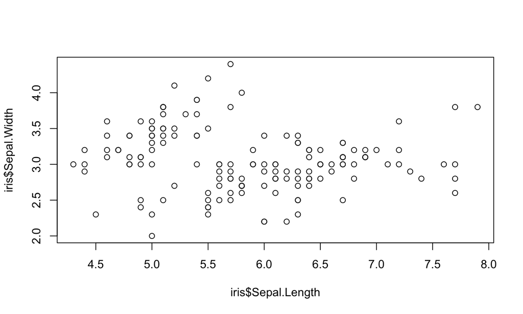

```r
plot(iris$Sepal.Length, iris$Sepal.Width)
```

## Creating a time series plot

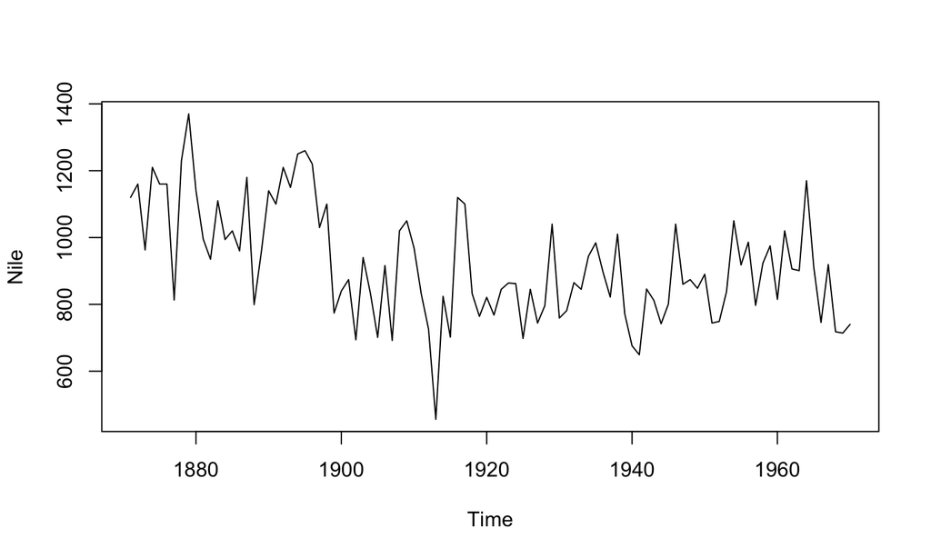

```r
plot(Nile)
```

## Creating a histogram

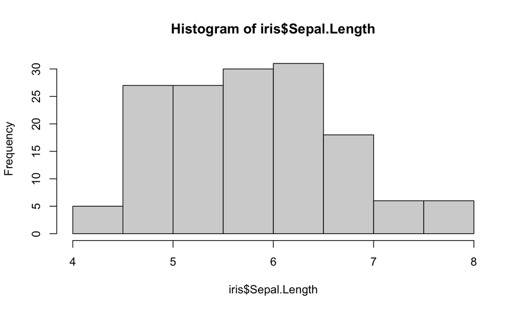

```r
hist(iris$Sepal.Length)
```

## Modeling data

The base `stats` package has many statistical functions:

- `lm()` → linear models
- `glm()` → generalized linear models
- See more: `library(help = "stats")`
- Many other packages

## Estimating a linear model

```r
lm(Sepal.Length ~ Sepal.Width + Species, iris)
```

```
##
## Call:
## lm(formula = Sepal.Length ~ Sepal.Width + Species, data = iris)
##
## Coefficients:
##       (Intercept)        Sepal.Width  Speciesversicolor   Speciesvirginica
##             2.251              0.804              1.459              1.947
```

```r
model <- lm(Sepal.Length ~ Sepal.Width + Species, iris)
AIC(model)
```

```
## [1] 183.94
```

```r
BIC(model)
```

```
## [1] 198.99
```

## Control flow

If this do that, else do something else

- `if ( ) { } else { }`
- `ifelse()` → vectorized

## Control flow example

```r
math <- function(x, y) {
  z <- x + y

  if (z > 10) {
    z * 2
  } else {
    z / 2
  }
}

math(2, 2)
```

```
## [1] 2
```

```r
math(7, 7)
```

```
## [1] 28
```

## Iteration

Do the same thing to multiple inputs

Two approaches to iteration:

- `for ( ) { }` and `while ( ) { }` loops
- `*apply()` family of functions → vectorized, preferred approach
  - `lapply()`, `sapply()`, `vapply()`, `tapply()`, `mapply()`
  - return different data structures

## Iteration example: `lapply()`

```r
data <- data.frame(matrix(rnorm(25), ncol = 5))
lapply(data, mean)
```

```
## $X1
## [1] 0.2186
##
## $X2
## [1] -0.44227
##
## $X3
## [1] -0.63754
##
## $X4
## [1] 0.71286
##
## $X5
## [1] 0.40627
```

## R scripts

- A script is a set of commands run in sequence
- Documents your analysis and workflows, enables reproducibility
- Text file saved with `.R` extension
- Write comments by starting line with `#`
- To run:
  - Within R console: `source()`
  - In the shell: `Rscript`

## Script example

```r
# Summarize subset of iris data

setosa <- iris[iris$Species == "setosa", ]

summary(setosa)
```

Save as `setosa.R`

In the shell, run with `Rscript setosa.R`

## Packages to consider

- `data.table` for speed
- `tidyverse` family of packages
  - `readr`, `tidyr`, `dplyr`, `purrr`
- `skimr` for better summary statistics
- `ggplot2` for advanced graphics
- `sf` for spatial data

## Additional resources

- [Using R on CARC Systems](https://carc.usc.edu/user-information/user-guides/software-and-programming/r)
- `install.packages("swirl")`
- [R for Reproducible Scientific Analysis lessons](https://swcarpentry.github.io/r-novice-gapminder/)
- [R Manuals](https://cran.r-project.org/manuals.html)
- Web books
  - [Hands-on Programming with R](https://rstudio-education.github.io/hopr/)
  - [An Introduction to R](https://intro2r.com/)
  - [R Programming for Data Science](https://bookdown.org/rdpeng/rprogdatascience/)
  - [R for Data Science](https://r4ds.had.co.nz/)